# Advanced Data Analysis from an Elementary Point of View - Notes

> These are my notes from lecture notes: Advanced Data Analysis from an Elementary Point of View. Person who wrote this: Cosma Rohilla Shalizi

# Contents

## Part I - Regression and its Generalizations

### 1 Regression Basics

Statistics is a branch of mathematical engineering that develops methods for making reliable inferences from imperfect data. Unlike sciences that study aspects of the world, statistics focuses on tools to help other sciences handle data, which is often incomplete, or noisy. Over the past two centuries, statistics has modeled these imperfections using probability, which is now central to its methods.

Statistics uses probability to understand and improve inference procedures - evaluating their reliability, error rates, and efficiency under various conditions. Key tools like regression help analyze relationships between variables. Regression also links to prediction, testing our understanding of these relationships and addressing “what if?” scenarios.

This book builds on foundational concepts of linear regression, exploring advanced methods for understanding and predicting relationships between variables, and positioning regression within broader family of smoothing techniques.

To predict a quantitative random variable $Y$, we aim to guess a single value, referred to as the **optimal point forecast**. Determining this requires defining a function to evaluate the quality of our guesses. A common choice is the **mean squared error** (MSE), which measures the average squared difference predictions and the true values. This provides a starting point for assessing and optimizing prediction.

$$MSE(m)\equiv\mathbb{E}\Big[(Y-m)^2\Big]\\
=(\mathbb{E}[Y-m])^2+\mathbb{V}[Y-m]\\
=(\mathbb{E}[Y-m])^2+\mathbb{V}[Y]\\
=(\mathbb{E}[Y]-m)^2+\mathbb{V}[Y]$$

Also expanding upon the variance - $\mathbb{V}[Y]$:

$$\mathbb{V}[Y]=\mathbb{E}[(Y-\mathbb{Y})^2]=
\mathbb{E}[Y^2]-(\mathbb{E}[Y])^2$$

Notice that only the first, bias-squared term depends on our prediction $m$. We want to find the derivative of the MSE with respect to our prediction $m$, and then set that to zero at the optimal prediction $\mu$:

$$\frac{dMSE}{dm}=-2(\mathbb{E}[Y]-m)+0\\
\frac{dMSE}{dm}\Bigg|_{m=\mu}=0\\
2(\mathbb{E}[Y]-\mu)=0\\
\mu=\mathbb{E}[Y]$$

To make the prediction $\mathbb{E}[Y]$ we would have to know the expected value of $Y$. Typically, we do not. However, if we have sampled values, $y_1$, $y_2$, …, $y_n$, we can estimate the expectation from the sample mean:

$$\hat{\mu}=\frac{1}{n}\sum^n_{i=1}y_i$$

If the samples are independent and identically distributed (IID), then the law of large numbers tells us that:

$$\hat{\mu}=\mathbb{E}[Y]=\mu$$

and algebra with variances tells us something about how fast the convergence is, namely that the squared error will typically be $\frac{\mathbb{V}[Y]}{n}$.

Of course the assumption that the $y_i$ come from IID samples is a strong one, but we can assert pretty much the same thing if they’re just uncorrelated with a common expected value. Even if they are correlated, but the correlations decay fast enough, all that changes is the rate of convergence.

> To demonstrate the power of linear regression in R, we can create a simple example where we fit a linear regression model to data and visualize its predictive ability.

We’ll simulate data with a linear relationship and some added noise

```r
set.seed(123) # For reproducibility
n <- 100
x <- rnorm(n, mean = 5, sd = 2) # Predictor variable
y <- 3 * x + 5 + rnorm(n, mean = 0, sd = 3) # Linear relationship with noise

# Create a data frame
data <- data.frame(x = x, y = y)
```

We use the lm() function to fit a linear regression model.

```r
# Fit a linear regression model
model <- lm(y ~ x, data = data)
summary(model)
```

```
Call:
lm(formula = y ~ x, data = data)

Residuals:
    Min      1Q  Median      3Q     Max
-5.7220 -2.0505 -0.2625  1.7419  9.8712

Coefficients:
            Estimate Std. Error t value Pr(>|t|)
(Intercept)   5.0851     0.8801   5.778 8.97e-08 ***
x             2.9213     0.1603  18.222  < 2e-16 ***
---
Signif. codes:  0 ‘***’ 0.001 ‘**’ 0.01 ‘*’ 0.05 ‘.’ 0.1 ‘ ’ 1

Residual standard error: 2.912 on 98 degrees of freedom
Multiple R-squared:  0.7721,    Adjusted R-squared:  0.7698
F-statistic:   332 on 1 and 98 DF,  p-value: < 2.2e-16
```

[output not shown]

```r
# Plot data and regression line
plot(data$x, data$y, main = "Linear Regression Example",
     xlab = "Predictor (x)", ylab = "Response (y)", pch = 16, col = "blue")
abline(model, col = "red", lwd = 2)  # Add regression line
```

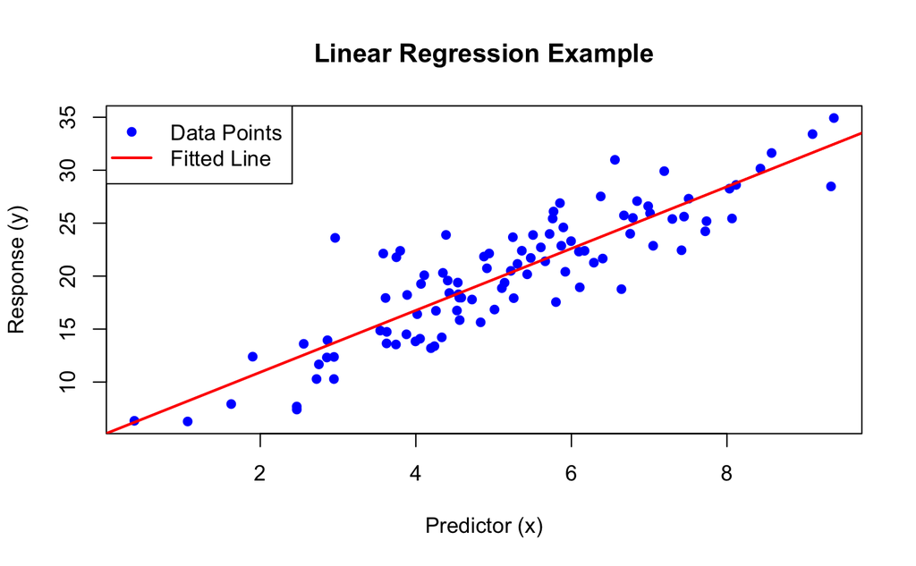

```r
legend("topleft", legend = c("Data Points", "Fitted Line"),
       col = c("blue", "red"), pch = c(16, NA), lwd = c(NA, 2))
```

We assess the model’s power by evaluating its performance using metrics such as $R^2$, residuals, and visualizing predictions.

```r
# Predicted values
data$predicted <- predict(model)

# Calculate R-squared manually
rss <- sum((data$y - data$predicted)^2)
tss <- sum((data$y - mean(data$y))^2)
r_squared <- 1 - (rss / tss)

cat("R-squared:", r_squared, "\n")
```

```
R-squared: 0.7721124
```

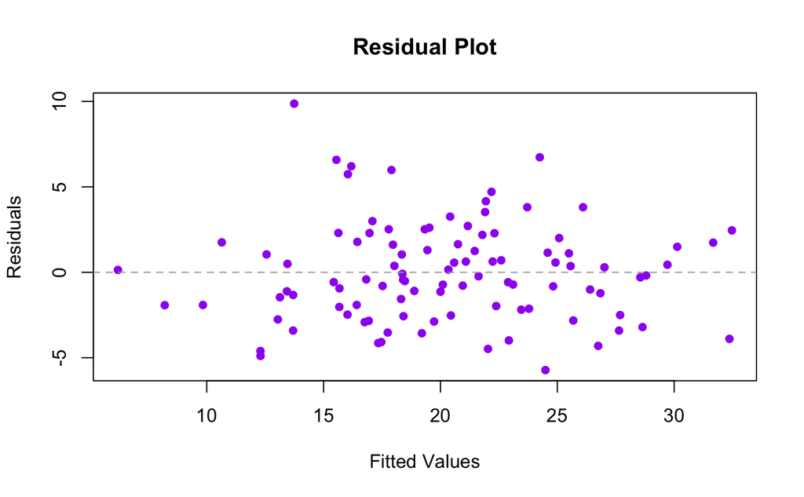

```r
# Plot residuals
plot(data$predicted, data$y - data$predicted,
     main = "Residual Plot", xlab = "Fitted Values", ylab = "Residuals",
     pch = 16, col = "purple")
abline(h = 0, col = "darkgray", lty = 2)
```

To demonstrate the predictive capability, we can split the data into training and testing sets:

```r
set.seed(123)
train_indices <- sample(1:n, size = 0.7 * n)
train_data <- data[train_indices, ]
test_data <- data[-train_indices, ]

# Fit model on training data
model_train <- lm(y ~ x, data = train_data)

# Predict on test data
test_data$predicted <- predict(model_train, newdata = test_data)

# Visualize actual vs predicted
plot(test_data$y, test_data$predicted, main = "Actual vs Predicted",
     xlab = "Actual Values", ylab = "Predicted Values", pch = 16, col = "darkgreen")
abline(0, 1, col = "red", lwd = 2)  # Perfect prediction line
```

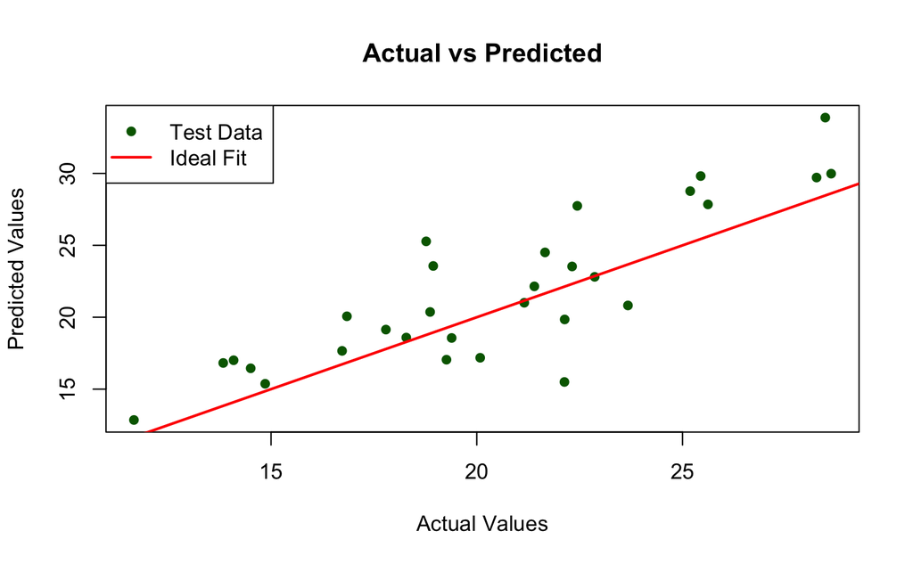

```r
legend("topleft", legend = c("Test Data", "Ideal Fit"),
       col = c("darkgreen", "red"), pch = c(16, NA), lwd = c(NA, 2))
```

This graph compares actual (x-axis) to predicted values (y-axis) for test data. The red line represents perfect predictions (y=x), and the green points show actual vs. predicted values. Closer points to the red line indicate better predictions. While the model is generally accurate, some points show significant errors. Larger deviations from the red line suggest areas where the model could be improved. Overall, the model performs well with room for refinement.

To predict using a function of $X$, $f(X)$, under mean squared error, we apply the law of total expectation: $\mathbb{E}[U]=\mathbb{E}[\mathbb{E}[U|V]]$.

$$MSE(f)=\mathbb{E}[(Y-f(X))^2]\\
=\mathbb{E}[\mathbb{E}[(Y-f(X))^2|X]]\\
=\mathbb{E}\Big[\mathbb{V}[Y-f(X)|X]+(\mathbb{E}[Y-f(X)|X])^2\Big]\\
=\mathbb{E}\Big[\mathbb{V}[Y|X]+(\mathbb{E}[Y-f(X)|X])^2\Big]$$

To minimize, the first term is independent of our prediction, and the second term mirrors prior optimization but conditional on $X$. Thus, the optimal function $\mu(x)$ is:

$$\mu(x)=\mathbb{E}[Y|X = x]$$

The optimal conditional prediction (mean-squared) is the conditional expected value, $\mu(x)$, also known as the true, optimal, or population regression function. This is key for predicting $Y$.

It’s important to be clear on what is and is not being assumed here. Talking about $X$ as the “independent variable” and $Y$ as the “dependent” one suggests a causal model, which we might write

$$Y\leftarrow \mu(X) + \epsilon$$

The equation $Y\rightarrow\mu(X)+\epsilon$ indicates that $Y$ depends on $X$ via $\mu(X)$, with $\epsilon$ representing noise. $\epsilon$ can often be assumed to have mean zero without loss of generality, as any non-zero mean can be absorbed into $\mu(X)$. This relationship works for predicting effects from causes, causes from effects, or even when $X$ and $Y$ are unrelated.

It is always true that

$$Y|X=\mu(X)+\epsilon(X)$$

where $\epsilon(X)$ is a random variable with expected value 0, $\mathbb{E}[\epsilon|X=x]=0$, but as the notation indicates the distribution of this variable generally depends on $X$.

If the regression function $\mu(x)$ is constant ($\mu(x)=\mu_0$ for all $x$), it does not imply that $X$ and $Y$ are statistically independent. Independence means $\mu(x)$ is constant, but the reverse assumption is a logical fallacy (“affirming the consequent”).

You can continue on page 25.

### 2 The Truth About Linear Regression

### 3 Model Evaluation

### 4 Smoothing in Regression

### 5 Simulation

### 6 The Bootstrap

### 7 Splines

### 8 Additive Models

### 9 Testing Regression Specifications

### 10 Weighting and Variance

### 11 Logistic Regression

### 12 GLMs and GAMs

### 13 Trees

## Part 2 - Distributions and Latent Structure

## Part 3 - Casual Inference

## Part 4 - Dependent data